# Practical 12.1 - Solutions

### Question 1

**1a.** *Download the data and read into R*.

```r
# You will need to change the pathway to where you have the data saved.
load("C:/Users/chloe/Documents/LSHTM/Teaching/2021/HDS_Lessons/Lesson_12/Practical/FEV.Rdata")
head(FEVdata)
```

A data.frame: 6 × 7

|  | id <int> | age <int> | fev <dbl> | height <dbl> | sex <fct> | smoke <fct> | region <chr> |
| --- | --- | --- | --- | --- | --- | --- | --- |
| 1 | 301 | 9 | 1.708 | 57.0 | female | non-current smoker | England |
| 2 | 451 | 8 | 1.724 | 67.5 | female | non-current smoker | England |
| 3 | 501 | 7 | 1.720 | 54.5 | female | non-current smoker | England |
| 4 | 642 | 9 | 1.558 | 53.0 | male | non-current smoker | England |
| 5 | 901 | 9 | 1.895 | 57.0 | male | non-current smoker | England |
| 6 | 1701 | 8 | 2.336 | 61.0 | female | non-current smoker | Scotland |

**1b.** *Use appropriate numerical summaries and graphical techniques to explore the distribution of FEV and age.*

```
   Min. 1st Qu.  Median    Mean 3rd Qu.    Max.
  0.791   1.981   2.547   2.637   3.119   5.793
```

```
   Min. 1st Qu.  Median    Mean 3rd Qu.    Max.
  3.000   8.000  10.000   9.931  12.000  19.000
```

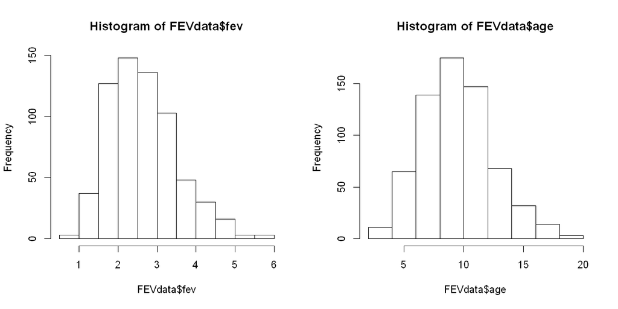

```r
par(mfrow=c(1,2))

#Sizing the plots (you won't need this code when doing this in R)
library(repr)
options(repr.plot.width=10, repr.plot.height=5)


hist(FEVdata$fev)
hist(FEVdata$age)

summary(FEVdata$fev)
summary(FEVdata$age)
```

The distribution of both FEV and age are right skewed. FEV ranges from 0.79 to 5.79 with a median of 2.5. The ages range from 3 to 19 years, with a median of 10 years.

**1c.** *Use graphical techniques to explore the relationship between FEV and age. Does there appear to be an association?*

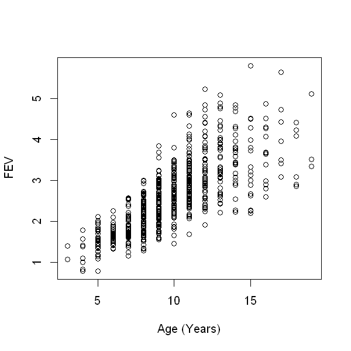

```r
#Sizing the plots (you won't need this code when doing this in R)
options(repr.plot.width=5, repr.plot.height=5)

par(mfrow=c(1,1))

plot(FEVdata$age, FEVdata$fev, ylab="FEV", xlab="Age (Years)")
```

Yes, there appears to be correlation between FEV and age. Older participants tend to have higher lung function.

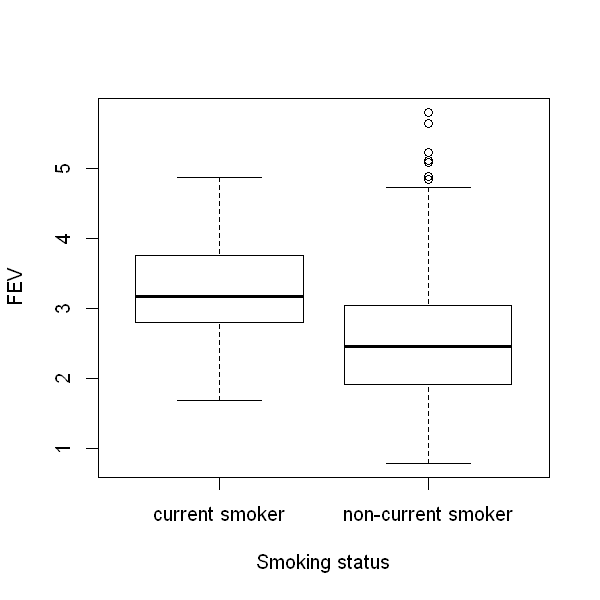

```r
boxplot(FEVdata$fev~FEVdata$smoke, xlab="Smoking status", ylab="FEV")
```

Yes, there appears to be an association. The median and interquartile range for FEV is higher for smokers compared to non-smokers indicating that smokers have higher FEV, on average.

### Question 2

**2a.** *Write down a simple linear regression model which relates FEV (as the outcome) and age, and define all components of the the model. What assumptions does this model make?*

$Y_i=\beta_0+\beta_1X_i+\epsilon_i$

Where:

- $Y_i$ is the FEV for the $i^{th}$ person
- $X_i$ is the age of the $i^{th}$ person, in years
- $\beta_0$ is the intercept
- $\beta_1$ is the slope
- $\epsilon_i$ is the error term for the $i^{th}$ person

Assumptions:

1. The mean FEV is a linear function of age.
2. The residuals are independent.
3. The variance of the residuals is constant.
4. The residuals are normally distributed.

**2b.** *Perform a linear regresion in R using FEV as the outcome and age as the independent variable (we will refer to this model as Model 1).*

```r
model1<-lm(fev~age, data=FEVdata)
```

**2c.** *Produce a scatter plot of FEV and age, including the regression line of best fit for Model 1 (if you are unsure how to code this in R, there is an example in 12.5.1 of the notes). What is the estimated intercept and slope of this line?*

```
Call:
lm(formula = fev ~ age, data = FEVdata)

Residuals:
     Min       1Q   Median       3Q      Max
-1.57539 -0.34567 -0.04989  0.32124  2.12786

Coefficients:
            Estimate Std. Error t value Pr(>|t|)
(Intercept) 0.431648   0.077895   5.541 4.36e-08 ***
age         0.222041   0.007518  29.533  < 2e-16 ***
---
Signif. codes:  0 '***' 0.001 '**' 0.01 '*' 0.05 '.' 0.1 ' ' 1

Residual standard error: 0.5675 on 652 degrees of freedom
Multiple R-squared:  0.5722,	Adjusted R-squared:  0.5716
F-statistic: 872.2 on 1 and 652 DF,  p-value: < 2.2e-16
```

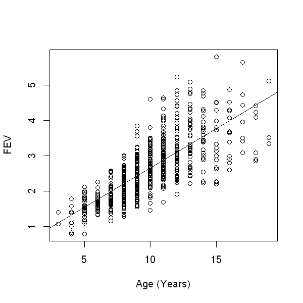

```r
plot(FEVdata$age, FEVdata$fev, ylab="FEV", xlab="Age (Years)")
abline(model1)
summary(model1)
```

The intercept is 0.432 and the slope is 0.222.

**2d.** *How are the intercept and slope interpreted?*

The intercept for Model 1 is interpreted as the mean FEV for participants aged 0 years. The slope is equal to 0.222 and this is interpreted as: the mean FEV is expected to increase by 0.222 for each yearly increase in age.

**2e.** *The `summary()` command provides t-test statistics and p-values for linear regression models. State the null and alternative hypotheses for the test associated with the estimated slope. What is the test statistic and p-value?*

- The null hypothesis: $H_0: \beta_1=0$ (i.e. there is no association between FEV and age).
- The alternative hypothesis: $H_1: \beta_1 \neq 0$ (i.e. there is an association between FEV and age).

The test statistic is 29.533 and the p-value is $<2.2e-16$

**2f.** *Calculate a 95% confidence interval for the estimated slope in R and check the results by hand.*

```r
confint(model1, parm=2, level=0.95)
```

A matrix: 1 × 2 of type dbl

|  | 2.5 % | 97.5 % |
| --- | --- | --- |
| age | 0.2072777 | 0.2368043 |

The 95% confidence interval for $\hat{\beta_1}$ is (0.207,0.237). By hand, we can use the following formula:

$\hat{\beta_1} \pm 1.96 \times \hat{SE}(\hat{\beta_1})$

Which gives us the same results: $0.2220 \pm 1.96 \times 0.0075 = (0.207, 0.237)$.

**2g.** *Based on the results from the hypothesis test and the confidence interval, is there evidence of an association between FEV and age?*

The p-value associated with our hypothesis was very small, indicating that the data provide strong evidence against the null hypothesis. Moreover, the 95% confidence interval does not contain the value 0 (as expected, given the results of the hypothesis test). Based on these results we can infer that there is an association between FEV and age: on average, the older the participant, the higher their FEV.

### Question 3

**3a** *Define a new variable "smoke_code" that takes value 0 for non-smokers and 1 for smokers. How many smokers and non-smokers are there in the data?*

```r
FEVdata$smoke_code<-0
FEVdata$smoke_code[FEVdata$smoke=="current smoker"]<-1
FEVdata$smoke_code<-as.factor(FEVdata$smoke_code)


table(FEVdata$smoke_code)
```

```
  0   1
589  65
```

There are 589 non-smokers and 65 current smokers in the data.

**3b** *Write a linear regression model with FEV as the outcome and smoking status as the independent covariate, and define all the components.*

$Y_i = \beta_0 + \beta_1X_{2i}+\epsilon_i$

Where:

- $Y_i$ is the FEV for the $i^{th}$ person.
- $X_{2i}$ is an indicator variable for smoking status. It equals 0 for non-smokers and 1 for current smokers.
- $\beta_0$ is the intercept of the $y$-axis when $X_2$ is equal to 0.
- $\beta_1$ is the regression coefficient for smoking status.
- $\epsilon_i$ is the error term for the $i^{th}$ person.

**3c** *Write down the above linear regression model in matrix form.*

Let $n=654$ (i.e. the total sample size). Then:

$$\begin{vmatrix}y_1\\y_2 \\. \\. \\y_n \end{vmatrix}=\begin{vmatrix}1 & x_{21} \\ 1 & x_{22} \\1 & . \\1 & . \\ 1& . \\1 & x_{2n} \end{vmatrix}\begin{vmatrix} \beta_0 \\ \beta_1 \\ \end{vmatrix}+\begin{vmatrix}\epsilon_1\\ \epsilon_2 \\ . \\. \\ \epsilon_n \end{vmatrix} $$

**3d** *Perform the multivariable linear regression in R. This new model is referred to as Model 2.*

```r
model2<-lm(fev~smoke_code, data=FEVdata)
summary(model2)
```

```
Call:
lm(formula = fev ~ smoke_code, data = FEVdata)

Residuals:
    Min      1Q  Median      3Q     Max
-1.7751 -0.6339 -0.1021  0.4804  3.2269

Coefficients:
            Estimate Std. Error t value Pr(>|t|)
(Intercept)  2.56614    0.03466  74.037  < 2e-16 ***
smoke_code1  0.71072    0.10994   6.464 1.99e-10 ***
---
Signif. codes:  0 '***' 0.001 '**' 0.01 '*' 0.05 '.' 0.1 ' ' 1

Residual standard error: 0.8412 on 652 degrees of freedom
Multiple R-squared:  0.06023,	Adjusted R-squared:  0.05879
F-statistic: 41.79 on 1 and 652 DF,  p-value: 1.993e-10
```

**3e** *What is the estimated intercept and estimated regression coefficient in Model 2 and how are they interpreted?*

The intercept for Model 2 is 2.6 and this is interpreted as the mean FEV for participants who do not smoke. The slope is equal to 0.7, which means the mean FEV is estimated to increase by 0.7 per unit increase in the "dummy" variable. A unit increase in the dummy variable equates to moving from the non-smoking group to the smoking group, so we can interpret this as: smokers, on average, have an FEV 0.7 higher than non-smokers.

**3f** *What is the expected FEV for a smoker and a non-smoker?*

```r
#Expected FEV for smokers
new.data<-data.frame(smoke_code="1")
predict(model2, new.data)

#Expected FEV for non-smokers
new.data<-data.frame(smoke_code="0")
predict(model2, new.data)
```

**1:** 3.27686153846154

**1:** 2.56614261460102

The expected FEV for a smoker is 3.28 and the expected FEV for a non-smoker is 2.57. Note that the expected FEV for a non-smoker is the same as the intercept given in the output above and the expected FEV for a smoker is the intercept plus the slope.

**3g** *Based on the results for Model 2, is there any evidence of an association between FEV and smoking?*

```r
confint(model2, parm=2, level=0.95)
```

A matrix: 1 × 2 of type dbl

|  | 2.5 % | 97.5 % |
| --- | --- | --- |
| smoke_code1 | 0.4948346 | 0.9266033 |

The p-value associated with the slope parameter in Model 2 is very small, indicated evidence against the null hypothesis that the association between FEV and smoking is 0. The 95% confidence interval for the slope parameter is (0.49, 0.93). As 0 is not indicated in this interval, this is further evidence of an association between FEV and smoking.

You may be suprised that the results indicate smokers are, on average, expected to have better lung function than non-smokers. In the next practical, we look at another model which helps explain this unexpected result.